## Monte Carlo Simulations for Power Estimation

A Monte Carlo simulation study was conducted for power estimation in the software Mplus (Muth?n & Muth?n, 2014). An introduction to Monte Carlo power analysis in Mplus is provided in Muthen and Muthen (2002). A discussion of the specification of intervention effects is given in Thoemmes, MacKinnon, and Reiser (2010).

### Aim of the Simulation Study

The aim of the simulation study was to estimate the power (probability of finding a significant effect) for detecting intervention effects of the Experimentation Skills Training and the MINT Curriculum. It should be evaluated at which smaple size the threshold for adequate power of >.80 is reached, and which power is reached with the maximum planned sample size of N = 1200.

### Basic Specifications for the Simulations

The simulations were run for sample sizes between N = 500 and N = 1200, increasing stepwise by n = 100. Each simulation was based on 10000 draws for the respective sample size. Power was estimated as the average of the two percentages of significant parameter estimates for the intervention effects of the Experimentation Skills Training and the MINT curriculum in the 10000 draws.

### Simulated Structural Equation Models

A two-level regression model was simulated with school classes as level two clusters (see e.g., Raudnbush & Bryk, 2002). For the population model from which the Monte Carlo samples were drawn, a regression of the posttest (e.g., Complex Solving Test, Experimentation Skills test, or Experimentation Skills Interview after the two interventions) on the pretest (the same respective test before the Experimentation Skills Training) was specified. The pretest served as predictor of the posttest on both levels of the analysis, that is, on the level of the individual student, and on the level of the school class (as class average). Crucially, on the between level the posttest was additionally regressed on the two intervention variables representing the effect of the Experimentation Skills Training (est) and of the MINT curriculum (mint).

## Results

Esimated power to detect the intervention effects in dependence of sample size is depicted in Figure 1. The threshold of power >.80 was reached at a sample size of N = 700. At the maximum planned sample size of 1200, power was estimated at .96. These results confirm that a sample size of between 700 and 1200 students can be seen optimal to detect small to moderate transfer effects with sufficiently high but not too high certainty and an optimal balance of alpha and beta error risk can be reached.

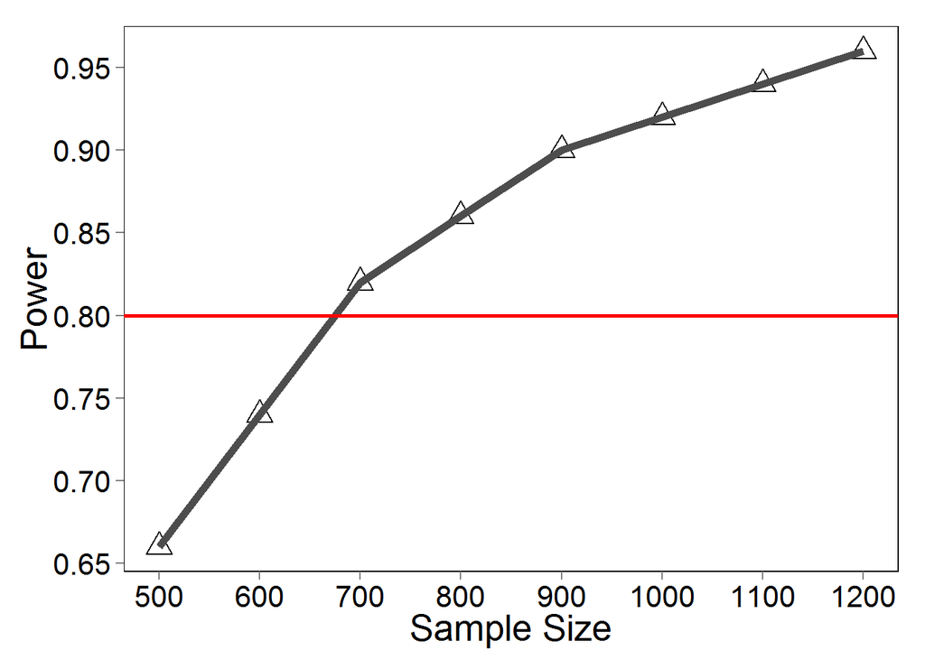

## References

Muth?n, B., & Muthen, L. (2002). How to decide on smaple size using Monte Carlo Simulations in Mplus. Structurla Equation Modeling, 2, 599-638. Muth?n, B., & Muthen, L. (2014). Mplus User’s Guide. Brooklyn, NY. Thoemmes, MacKinnon, and Reiser (2010). Power Analysis for Complex Mediational Models in Mplus. Structurla Equation Modeling, 12, 99-128.

## Commented Mplus sample input syntax file for N = 700

montecarlo: ! Define simulated variables names are post ! Complex Problem Solving posttest pre ! Compelx Problem Solving pretest est ! Intervention 1: Expeirmentation Skills Training mint;! Intervention 2: MINT curriculum nobservations = 700; ! Total sample size for each Monte Carlo-draw ncsizes = 5; ! Nubmer of different classroom sizes ! Classroom sample: Overall 35 Classrooms with 10 - 30 children csizes = 4 (10) 8 (15) 11 (20) 8 (25) 4 (30); ! Number and size of the 35 classrooms ! Define intervention variable (>.5 = intervention group; ! see Thoemmes, MacKinnon, & Reiser, 2010) cutpoints = est (.5) mint (.5); ! Define missing values PATMISS = post (.10); ! 10% of posttest-data on CPS are missing PATPROBS = 1; ! Define seed for quasi-random number generation seed = 666; ! Define number of Monte Carlo draws from the population nreps = 10000; ! Define variables on second level (school class level) between = est mint; ! The interventions happen on the classroom level !save = MCTransfer_*.dat; ! Activate to save sampled data !repsave = all; ! Activate to save sampled data

ANALYSIS: TYPE = TWOLEVEL;

model population:

```
    %within%
    ! Posttest-residual variance
    post*2; ! Retest-reliability .80 20% variance not explained by pre-test
    pre*10; ! Pretest-variance within classrooms
    post ON pre*.894; ! Pretest explains 80% (.894^2) of posttest

    %between%
    post*.10; ! 10% of posttest-variance unexplained
    pre*1; ! Pretest-variance between classrooms
    [est*.5]; ! Mean of "est" intervention variable
    ! Variance of "est" intervention variable
    est*.25; ! .25 so that SD = .5
    [mint*.5]; ! Mean of "mint" intervention variable
    ! Variance of "mint" intervention variable
    mint*.25; ! .25 so that SD = .5
    ! Regression of posttest variance between classrooms
    post ON pre*.949 est*.447 mint*.447; ! .90 explained by pretest (.949^2*1),
                                         ! .05 by est (.447^2*.25),
                                         ! .05 by mint (.447^2*.25)
                                         ! = 1.00 explained variance,
                                         ! .10 non-explained,
                                         ! sums up to variance of 1.10 at posttest
                                         ! which makes up an ICC of about .10
```

model: ! Same as population model without mentioning ! means and variances of exogenous variables %within% post*2;

```
    post ON pre*.894;

    %between%
    post*.10;



    post ON pre*.949 est*.447 mint*.447;
```

output: tech9; ! Show simulation results